# VPP学习

说明： 本文章内容大量摘取于网络，如有原作者要求删除，请联系jialejiahi@163.com

2018年3月1日

# 1 什么是VPP

VPP是思科贡献给FD.io项目组的一个开源项目，它实现了用户态的一个快速转发平面。要进一步了解VPP是什么，可以参考官网介绍: https://wiki.fd.io/view/VPP/What_is_VPP%3F VPP的好处是它的高性能，经过Cisco商业产品验证， 模块性和扩展性， 以及丰富的feature。其feature包括但不限于二层交换，三层路由，ACL， QoS， IPsec等。与dpdk结合，把dpdk_input作为vpp的一个输入node，VPP可以实现比较高的网络性能。

VPP的各个网络功能模块被称为一个个的Node，数据包以packet vector的形式在各个Node之间流动。DPO和feature机制是新引入的在Node结构之上的模块组织方式。

vpp的整体包处理框架如下图所示：

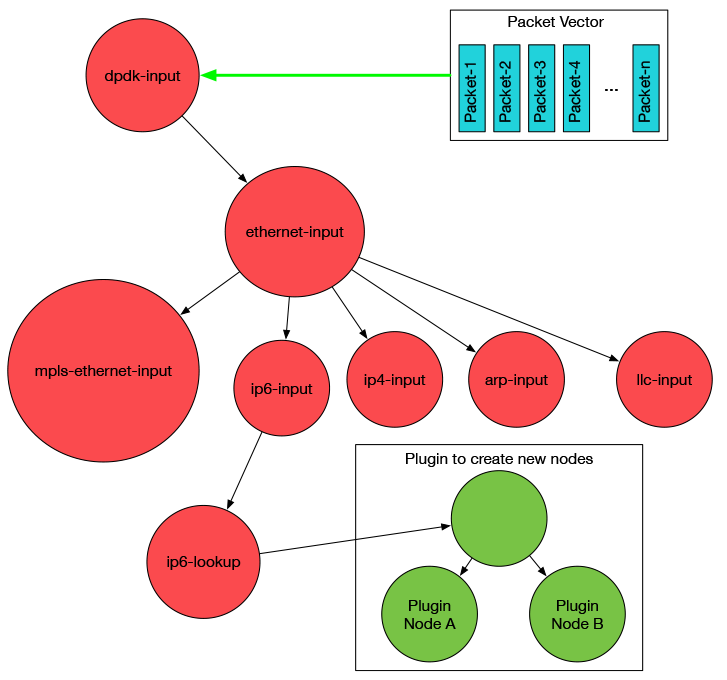

# 2 主要代码目录结构

| 目录 | 功能 |
| --- | --- |
| vppinfra | 提供一些基本的通用的功能函数库：包括内存管理，向量，hash，堆，图， timer等 |
| vlib | 提供基本的应用管理库：buffer管理，graph node管理，线程，CLI，trace等 |
| vnet | 提供基本网络功能，如接口管理，L2,L3,L4功能，ipsec, session管理，控制管理，流量管理等 |
| plugins | 提供部分更顶层的网络功能，以及与第三方软件的适配，大多以一个node的方式实现 |
| svm | 共享内存代码库实现，如queue， fifo， db等 |
| vpp | 程序的总入口与整个工程的组织代码，main函数代码在该目录 |

# 3 编译和运行配置

1. vpp的开源代码用git进行版本控制和管理，获取代码命令如下：

```
git clone ssh://USERNAME@gerrit.fd.io:29418/vpp.git
```

2. 代码编译

vpp可以跑在普通的x86平台，centos操作系统，整个工程用build-root进行编译，初次编译需下载依赖包，脚本 `build-root/vagrant/build.sh` 可以完成第一次编译时的准备工作。 主Makefile就在vpp代码的根目录下，执行如下命令进行编译

```
make install-dep
make bootstrap
make build        # or `make build-release`
```

3. 编译结果与安装运行

通过上面编译命令，编译出的二进制程序和库在目录 build-root/install-vpp-native之下 可以通过编译出的二进制文件VPP启动主程序和CLI,程序的的配置文件默认为/etc/vpp/statrtup.conf 在启动配置文件中指定的配置选项与代码中是类似的。 配置选项中比较重要的包括：

1. cpu参数，指定用几个CPU，用哪几个CPU。
2. dpdk参数，指定dpdk接管哪些设备，设备的报文buffer空间大小，KNI接口数量等

vpp支持控制面和数据处理都在一个核上的单核运行模式，也支持多核模式。 具体配置文件和多核运行配置方式参考：

https://wiki.fd.io/view/VPP/Command-line_Arguments

https://wiki.fd.io/view/VPP/Using_VPP_In_A_Multi-thread_Model

# 4 关键代码分析

## 4.1 初始化

程序入口函数是vpp/vnet/main.c中的main函数，该函数处理调用流程如下

[figure not shown]

通过调用流程`main->vlib_unix_main->thread0->vlib_main`会调用到vlib_main函数 vlib_main函数调用图如下：

[figure not shown]

## 4.2 node调度框架

函数`lib_main_loop->vlib_main_or_worker_loop` 会执行到vpp程序的主线程循环：

```cpp
static void vlib_main_or_worker_loop (vlib_main_t * vm)
{
    ...

    //dpdk收包时下面用不到。它们是用来模拟标准网卡NAPI机制的
    if (!nm->polling_threshold_vector_length)
        nm->polling_threshold_vector_length = 10;
    if (!nm->interrupt_threshold_vector_length)
        nm->interrupt_threshold_vector_length = 5;

    nm->current_process_index = ~0;

    /*
     * 执行所有VLIB_NODE_TYPE_PROCESS类型node，利用setjump，longjump机制，
     * 把node挂起来，等待之后唤醒。
     * 可以理解为一种多任务模型。该类型node主要时用在作运行时配置相关。
     * 之后会详细论述该类型node。
     */
    uword i;
    for (i = 0; i < vec_len (nm->processes); i++)
        cpu_time_now =
                dispatch_process (vm, nm->processes[i], /* frame */ 0, cpu_time_now);

    while (1)
    {
        vlib_node_runtime_t *n;

        //目前只有一个epoll相关的node，监听socket，辅助功能
        vec_foreach (n, nm->nodes_by_type[VLIB_NODE_TYPE_PRE_INPUT])
            cpu_time_now = dispatch_node (vm, n,
                    VLIB_NODE_TYPE_PRE_INPUT,
                    VLIB_NODE_STATE_POLLING,
                    /* frame */ 0,
                    cpu_time_now);

        //收包node，假设使用dpdk的node
        vec_foreach (n, nm->nodes_by_type[VLIB_NODE_TYPE_INPUT])
            cpu_time_now = dispatch_node (vm, n,
                    VLIB_NODE_TYPE_INPUT,
                    VLIB_NODE_STATE_POLLING,
                    /* frame */ 0,
                    cpu_time_now);

        //memclnt_node会用到，但是博主发现该node没有使用。无视之。
        if (PREDICT_TRUE (vm->queue_signal_pending == 0))
            vm->queue_signal_callback (vm);

        //dpdk没有中断机制，这里不会执行
        {
            ...
        }

        /*
         * 处理超时事件，通过api发生的唤醒node事件。
         * 只对VLIB_NODE_TYPE_PROCESS类型node有效。
         * VLIB_NODE_TYPE_PROCESS类型node处理需要单独描述，
         * 但不是开发人员关注的重点，只是配置相关。
         */
        nm->data_from_advancing_timing_wheel
                = timing_wheel_advance (&nm->timing_wheel, cpu_time_now,
                nm->data_from_advancing_timing_wheel,
                &nm->cpu_time_next_process_ready);

        ...

        /*
         * 真正开发人员关注的重点，数据包处理的核心逻辑都在VLIB_NODE_TYPE_INTERNAL类型node中。
         * nm->pending_frames记录了上一个node转给下一个node信息，
         * 最后可以找到传递给下一个node使用的数据包
         */
        for (i = 0; i < _vec_len (nm->pending_frames); i++)
            cpu_time_now = dispatch_pending_node (vm, nm->pending_frames + i,
                    cpu_time_now);
    }
}
```

main loop中调用到的dispatch_pending_node函数负责对数据包进行分发和处理：

```cpp
u64 dispatch_pending_node (vlib_main_t * vm,
               vlib_pending_frame_t * p, u64 last_time_stamp)
{
    vlib_node_main_t *nm = &vm->node_main;
    vlib_frame_t *f;
    vlib_next_frame_t *nf, nf_dummy;
    vlib_node_runtime_t *n;
    u32 restore_frame_index;

    //之后将执行n的业务逻辑
    n = vec_elt_at_index (nm->nodes_by_type[VLIB_NODE_TYPE_INTERNAL],
            p->node_runtime_index);

    //node n的对应frame，里面包含了node需要处理的数据包
    f = vlib_get_frame (vm, p->frame_index);
    /*
     * 不是下一跳传过来的数据包，比如自己生成的包注入某个node，此时if判断为真。
     * vlib_put_frame_to_node()完成注入逻辑。
     */
    if (p->next_frame_index == VLIB_PENDING_FRAME_NO_NEXT_FRAME)
    {
        nf = &nf_dummy;
        nf->flags = f->flags & VLIB_NODE_FLAG_TRACE;
        nf->frame_index = ~p->frame_index;
    }
    else
        //通过node下一跳传递来的数据包
        nf = vec_elt_at_index (nm->next_frames, p->next_frame_index);

    /*
     * node传递数据包到下一个node是通过调用vlib_put_next_frame()接口:
     * p->frame_index = nf->frame_index;
     * p->node_runtime_index = nf->node_runtime_index;
     * p->next_frame_index = nf - nm->next_frames;
     */
    if (nf->frame_index == p->frame_index)
    {
        //有两个位置同时引用了frame，把nf中的清掉，以免干扰本线程对frame的使用。
        nf->frame_index = ~0;
        nf->flags &= ~VLIB_FRAME_IS_ALLOCATED;
        if (!(n->flags & VLIB_NODE_FLAG_FRAME_NO_FREE_AFTER_DISPATCH))
            restore_frame_index = p->frame_index;
    }

    ...

    //调度node业务逻辑
    last_time_stamp = dispatch_node (vm, n,
            VLIB_NODE_TYPE_INTERNAL,
            VLIB_NODE_STATE_POLLING,
            f, last_time_stamp);

    f->flags &= ~VLIB_FRAME_PENDING;

    //frame已经在业务逻辑中使用完了，重新保存到nf中
    if (restore_frame_index != ~0)
    {
        //vlib_next_frame_change_ownership()可能会修改p->next_frame_index
        nf = vec_elt_at_index (nm->next_frames, p->next_frame_index);
        nf->frame_index = restore_frame_index;
        nf->flags |= VLIB_FRAME_IS_ALLOCATED;
    }

    return last_time_stamp;
}
```

## 4.3 dpdk node分析

dpdk收到的数据包用rte_mbuf结构描述。vpp为了兼容其它收包node（netmap，pcap等）改为使用vlib_buffer_t来描述数据包。

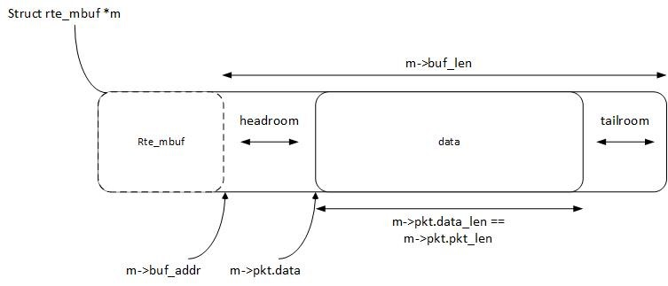

vlib_buffer_t紧跟在rte_mbuf后面，headroom空间中。 vlib_buffer_from_rte_mbuf和rte_mbuf_from_vlib_buffer完成相互转化。 值得注意的是，该结构使用了三个CLIB_CACHE_LINE_ALIGN_MARK宏，把结构分成了3段，确保每段都是CLIB_CACHE_LINE_BYTES对齐。作为一个被频繁使用的结构，这样设计可以更好的更具需要进行内存预取。

vlib_get_next_frame，vlib_put_next_frame是几乎每个node中必定出现的一对函数。vlib_get_next_frame获取传递给下一个node的数据包将驻留的内存结构。vlib_put_next_frame把传递给下一个node的数据包写入特定位置。这样下一个node将正式可以被调度框架调度，并处理传给他的数据包。

dpdk node的核心函数是dpdk_device_input

```cpp
//use_efd指定是否启用early-fast-discard特性。
static inline u32 dpdk_device_input (dpdk_main_t * dm,
           dpdk_device_t * xd,
           vlib_node_runtime_t * node,
           u32 cpu_index, u16 queue_id, int use_efd)
{
    u32 n_buffers;
    /*
     * 缺省情况下一跳是ethernet node，之后可以最终改变下一跳，
     * 个人认为这里使用next_index = node->cached_next_index会更合理
     */
    u32 next_index = DPDK_RX_NEXT_ETHERNET_INPUT;

    ...

    //网卡必须up了
    if (xd->admin_up == 0)
        return 0;

    //指定网卡的指定队列上收一批包，返回收到的包个数，
    //数据包地址存在xd->rx_vectors[queue_id]中。
    n_buffers = dpdk_rx_burst (dm, xd, queue_id);

    if (n_buffers == 0)
    {
        //看来EFD是默认不使用EFD。
        if (PREDICT_FALSE (use_efd && dm->efd.enabled))
        {
            xd->efd_agent.last_poll_time = 0;
            xd->efd_agent.last_burst_sz = 0;
        }
        return 0;
    }

    /*
     * vlib_buffer有多个pool，可以用在自己构建的数据包，
     * 这里的fl仅仅用来作为模板初始化ret_mbuf后面的vlib_buffer结构。
     */
    fl = vlib_buffer_get_free_list (vm, VLIB_BUFFER_DEFAULT_FREE_LIST_INDEX);

    if (PREDICT_FALSE (use_efd && dm->efd.enabled))
    {
        //一次收包到了VLIB_FRAME_SIZE个，如果这种情况次数很多，
        //说明发生了收包端拥塞，可以在后面直接丢弃数据包。
        if (PREDICT_FALSE (xd->efd_agent.consec_full_frames_cnt >=
                dm->efd.consec_full_frames_hi_thresh))
        {
            u32 device_queue_sz = rte_eth_rx_queue_count (xd->device_index,
                    queue_id);
            if (device_queue_sz >= dm->efd.queue_hi_thresh)
            {
                /* dpdk device queue has reached the critical threshold */
                xd->efd_agent.congestion_cnt++;

                /* apply EFD to packets from the burst */
                efd_discard_burst = 1;
            }
        }
    }

    mb_index = 0;

    while (n_buffers > 0)
    {
        //to_next指向的内存用来保存数据包地址，n_left_to_next保存数据包地址的内存最大剩余空间
        vlib_get_next_frame (vm, node, next_index, to_next, n_left_to_next);

        while (n_buffers > 0 && n_left_to_next > 0)
        {
            if (PREDICT_TRUE (n_buffers > 2))
            {
                /*
                 * 把之后需要使用的数据包内存预取一下。
                 * 为什么预取2个包以后的而不是下一个包？疑惑。
                 * 内存预取所花费的cpu周期,博主有时间在定量分析下。
                 */
                struct rte_mbuf *pfmb = xd->rx_vectors[queue_id][mb_index + 2];
                vlib_buffer_t *bp = vlib_buffer_from_rte_mbuf (pfmb);
                CLIB_PREFETCH (pfmb, CLIB_CACHE_LINE_BYTES, STORE);
                CLIB_PREFETCH (bp, CLIB_CACHE_LINE_BYTES, STORE);
            }

            //拥塞发生了，丢包
            if (PREDICT_FALSE (efd_discard_burst))
            {
                vlib_thread_main_t *tm = vlib_get_thread_main ();

                if (PREDICT_TRUE (cntr_type = is_efd_discardable (tm, b0, mb)))
                {
                    rte_pktmbuf_free (mb);
                    xd->efd_agent.discard_cnt++;
                    increment_efd_drop_counter (vm, cntr_type, 1);
                    n_buffers--;
                    mb_index++;
                    continue;
                }
            }

            if (PREDICT_FALSE (mb->nb_segs > 1))
            {
                //又是内存预取
                struct rte_mbuf *pfmb = mb->next;
                vlib_buffer_t *bp = vlib_buffer_from_rte_mbuf (pfmb);
                CLIB_PREFETCH (pfmb, CLIB_CACHE_LINE_BYTES, LOAD);
                CLIB_PREFETCH (bp, CLIB_CACHE_LINE_BYTES, STORE);
                b_chain = b0;
            }

            //取用fl中的模板给b0初始化,这个函数在赋值时，
            //如果cpu支持128bit向量，则可以每次赋值拷贝16个字节(u8x16类型支持)。
            vlib_buffer_init_for_free_list (b0, fl);

            //vlib_buffer转换为偏移量，注意地址都是1 << CLIB_LOG2_CACHE_LINE_BYTES对齐
            bi0 = vlib_get_buffer_index (vm, b0);

            //数据包写入缓存，下一跳node将会使用
            to_next[0] = bi0;
            to_next++;
            n_left_to_next--;

            //决定下一跳node，默认情况下会根据3层协议来决定下一跳。
            //如果自己hook了，则条转给指定的node
            dpdk_rx_next_and_error_from_mb_flags_x1 (xd, mb, b0,
                    &next0, &error0);

            ...

            //这里有bug？
            //应该是b0->current_data += mb->data_off - sizeof(struct vlib_buffer_t)
            b0->current_data += mb->data_off - RTE_PKTMBUF_HEADROOM;
            b0->current_length = mb->data_len - l3_offset0;

            ...

            while ((mb->nb_segs > 1) && (nb_seg < mb->nb_segs))
            {
                ...
            }

            vlib_validate_buffer_enqueue_x1 (vm, node, next_index,
                       to_next, n_left_to_next,
                       bi0, next0);
            n_buffers--;
            mb_index++;
        }
        //调度框架之后就可以调度下一跳node处理上文传入的数据包集合了。
        vlib_put_next_frame (vm, node, next_index, n_left_to_next);
    }

    ...

    //多线程模型下，可以使用多个dpdk线程收包。
    dpdk_worker_t *dw = vec_elt_at_index (dm->workers, cpu_index);
    dw->aggregate_rx_packets += mb_index;

    return mb_index;
}
```